# Lab 4

Eric Steyer

3/18/2021

```r
library(readxl)
defense <- read_excel('cyclonesFootball2020.xlsx', sheet='Defensive')
str(defense)
```

```
## tibble [372 x 11] (S3: tbl_df/tbl/data.frame)
##  $ Name             : chr [1:372] "Rose, Mike" "Rose, Mike" "Rose, Mike" "Rose, Mike" ...
##  $ Opponent_Opponent: chr [1:372] "Louisiana" "TCU" "Oklahoma" "Texas Tech" ...
##  $ Tackles_Solo     : chr [1:372] "2" "6" "6" "3" ...
##  $ Tackles_ASST     : chr [1:372] "4" "4" "5" "0" ...
##  $ Tackles_TFL      : chr [1:372] "1.0" "0" "1.5" "1.0" ...
##  $ Tackles_Sack     : chr [1:372] "0" "0" "0.5" "0" ...
##  $ Turnover_FF      : chr [1:372] "0" "0" "0" "0" ...
##  $ Turnover_FR      : chr [1:372] "0" "0" "0" "0" ...
##  $ Turnover_INT     : chr [1:372] "0" "1" "0" "0" ...
##  $ Pass_QBH         : chr [1:372] "0" "0" "1" "0" ...
##  $ Pass_PB          : chr [1:372] "0" "0" "0" "0" ...
```

```r
offense <- read_excel('cyclonesFootball2020.xlsx', sheet='Offensive')
str(offense)
```

```
## tibble [156 x 12] (S3: tbl_df/tbl/data.frame)
##  $ Name             : chr [1:156] "Akers, Landen" "Akers, Landen" "Akers, Landen" "Akers, Landen" ...
##  $ Opponent_Opponent: chr [1:156] "Louisiana" "TCU" "Oklahoma" "Texas Tech" ...
##  $ Receiving_REC    : chr [1:156] "0" "2" "1" "4" ...
##  $ Receiving_YDS    : chr [1:156] "0" "60" "35" "34" ...
##  $ Receiving_TD     : chr [1:156] "0" "0" "0" "0" ...
##  $ Rushing_ATT      : chr [1:156] NA NA NA NA ...
##  $ Rushing_YDS      : chr [1:156] NA NA NA NA ...
##  $ Rushing_TD       : chr [1:156] NA NA NA NA ...
##  $ Passing_CMP-ATT  : chr [1:156] NA NA NA NA ...
##  $ Passing_YDS      : chr [1:156] NA NA NA NA ...
##  $ Passing_TD       : chr [1:156] NA NA NA NA ...
##  $ Passing_INT      : chr [1:156] NA NA NA NA ...
```

```r
biography <- read_excel('cyclonesFootball2020.xlsx', sheet='Biography')
str(biography)
```

```
## tibble [116 x 7] (S3: tbl_df/tbl/data.frame)
##  $ Name      : chr [1:116] "Akers, Landen" "Allen, Chase" "Anderson, Ezeriah" "Antoine Jr. , Michal" ...
##  $ Position  : chr [1:116] "Wide Receiver" "Tight End" "Wide Receiver" "Defensive Back" ...
##  $ Height    : chr [1:116] "6-0" "6-7" "6-5" "6-0" ...
##  $ Weight    : chr [1:116] "191" "240" "208" "180" ...
##  $ Class     : chr [1:116] "Redshirt Senior" "Redshirt Senior" "Redshirt Freshman" "Freshman" ...
##  $ Hometown  : chr [1:116] "Cedar Rapids, Iowa" "Nixa, Mo." "Seffner, Fla." "Ft. Lauderdale, Fla." ...
##  $ Highschool: chr [1:116] "Washington" "Nixa" "Armwood" "Cardinal Gibbons" ...
```

## Part One

```r
defense$Name <- as.factor(defense$Name)
defense$Opponent_Opponent <- as.factor(defense$Opponent_Opponent)
offense$Name <- as.factor(offense$Name)
offense$Opponent_Opponent <- as.factor(offense$Opponent_Opponent)
biography$Name <- as.factor(biography$Name)
```

```r
library(dplyr)
library(tidyr)
offense <- offense %>% separate(`Passing_CMP-ATT`, c("Pass_comp","Pass_att")) %>% mutate(Comp_Pct = as.numeric(Pass_comp) / as.numeric(Pass_att))
```

```r
head(offense)
```

```
## # A tibble: 6 x 14
##   Name     Opponent_Oppone~ Receiving_REC Receiving_YDS Receiving_TD Rushing_ATT
##   <fct>    <fct>            <chr>         <chr>         <chr>        <chr>
## 1 Akers, ~ Louisiana        0             0             0            <NA>
## 2 Akers, ~ TCU              2             60            0            <NA>
## 3 Akers, ~ Oklahoma         1             35            0            <NA>
## 4 Akers, ~ Texas Tech       4             34            0            <NA>
## 5 Akers, ~ Oklahoma St.     0             0             0            <NA>
## 6 Akers, ~ Kansas           6             76            0            <NA>
## # ... with 8 more variables: Rushing_YDS <chr>, Rushing_TD <chr>,
## #   Pass_comp <chr>, Pass_att <chr>, Passing_YDS <chr>, Passing_TD <chr>,
## #   Passing_INT <chr>, Comp_Pct <dbl>
```

```r
head(defense)
```

```
## # A tibble: 6 x 11
##   Name       Opponent_Oppone~ Tackles_Solo Tackles_ASST Tackles_TFL Tackles_Sack
##   <fct>      <fct>            <chr>        <chr>        <chr>       <chr>
## 1 Rose, Mike Louisiana        2            4            1.0         0
## 2 Rose, Mike TCU              6            4            0           0
## 3 Rose, Mike Oklahoma         6            5            1.5         0.5
## 4 Rose, Mike Texas Tech       3            0            1.0         0
## 5 Rose, Mike Oklahoma St.     7            3            1.0         0
## 6 Rose, Mike Kansas           4            1            0           0
## # ... with 5 more variables: Turnover_FF <chr>, Turnover_FR <chr>,
## #   Turnover_INT <chr>, Pass_QBH <chr>, Pass_PB <chr>
```

```r
head(biography)
```

```
## # A tibble: 6 x 7
##   Name          Position    Height Weight Class       Hometown      Highschool
##   <fct>         <chr>       <chr>  <chr>  <chr>       <chr>         <chr>
## 1 Akers, Landen Wide Recei~ 6-0    191    Redshirt S~ Cedar Rapids~ Washington
## 2 Allen, Chase  Tight End   6-7    240    Redshirt S~ Nixa, Mo.     Nixa
## 3 Anderson, Ez~ Wide Recei~ 6-5    208    Redshirt F~ Seffner, Fla. Armwood
## 4 Antoine Jr. ~ Defensive ~ 6-0    180    Freshman    Ft. Lauderda~ Cardinal Gi~
## 5 Assalley, Co~ Placekicker 6-0    195    Redshirt S~ Naperville, ~ Central
## 6 Azunna, Arno~ Defensive ~ 6-0    199    Redshirt S~ Grand Prairi~ Lake Ridge
```

```r
defClean <- defense %>% mutate(across(3:11, as.numeric))
offClean <- offense %>% mutate(across(3:14, as.numeric))
biography <- biography %>% mutate(Weight=as.numeric(Weight))

head(defClean)
```

```
## # A tibble: 6 x 11
##   Name       Opponent_Oppone~ Tackles_Solo Tackles_ASST Tackles_TFL Tackles_Sack
##   <fct>      <fct>                   <dbl>        <dbl>       <dbl>        <dbl>
## 1 Rose, Mike Louisiana                   2            4         1            0
## 2 Rose, Mike TCU                         6            4         0            0
## 3 Rose, Mike Oklahoma                    6            5         1.5          0.5
## 4 Rose, Mike Texas Tech                  3            0         1            0
## 5 Rose, Mike Oklahoma St.                7            3         1            0
## 6 Rose, Mike Kansas                      4            1         0            0
## # ... with 5 more variables: Turnover_FF <dbl>, Turnover_FR <dbl>,
## #   Turnover_INT <dbl>, Pass_QBH <dbl>, Pass_PB <dbl>
```

```r
head(offClean)
```

```
## # A tibble: 6 x 14
##   Name     Opponent_Oppone~ Receiving_REC Receiving_YDS Receiving_TD Rushing_ATT
##   <fct>    <fct>                    <dbl>         <dbl>        <dbl>       <dbl>
## 1 Akers, ~ Louisiana                    0             0            0          NA
## 2 Akers, ~ TCU                          2            60            0          NA
## 3 Akers, ~ Oklahoma                     1            35            0          NA
## 4 Akers, ~ Texas Tech                   4            34            0          NA
## 5 Akers, ~ Oklahoma St.                 0             0            0          NA
## 6 Akers, ~ Kansas                       6            76            0          NA
## # ... with 8 more variables: Rushing_YDS <dbl>, Rushing_TD <dbl>,
## #   Pass_comp <dbl>, Pass_att <dbl>, Passing_YDS <dbl>, Passing_TD <dbl>,
## #   Passing_INT <dbl>, Comp_Pct <dbl>
```

```r
bioClean <- biography %>% separate(Height, c("feet","inches"), sep='-') %>% mutate(Height = as.numeric(feet)*12 + as.numeric(inches)) %>% select(-feet:-inches)

head(bioClean)
```

```
## # A tibble: 6 x 7
##   Name          Position    Weight Class       Hometown      Highschool   Height
##   <fct>         <chr>        <dbl> <chr>       <chr>         <chr>         <dbl>
## 1 Akers, Landen Wide Recei~    191 Redshirt S~ Cedar Rapids~ Washington       72
## 2 Allen, Chase  Tight End      240 Redshirt S~ Nixa, Mo.     Nixa             79
## 3 Anderson, Ez~ Wide Recei~    208 Redshirt F~ Seffner, Fla. Armwood          77
## 4 Antoine Jr. ~ Defensive ~    180 Freshman    Ft. Lauderda~ Cardinal Gi~     72
## 5 Assalley, Co~ Placekicker    195 Redshirt S~ Naperville, ~ Central          72
## 6 Azunna, Arno~ Defensive ~    199 Redshirt S~ Grand Prairi~ Lake Ridge       72
```

## Part Two

```r
offClean <- offClean %>% pivot_longer(c(3:14),names_to = "stat")

head(offClean)
```

```
## # A tibble: 6 x 4
##   Name          Opponent_Opponent stat          value
##   <fct>         <fct>             <chr>         <dbl>
## 1 Akers, Landen Louisiana         Receiving_REC     0
## 2 Akers, Landen Louisiana         Receiving_YDS     0
## 3 Akers, Landen Louisiana         Receiving_TD      0
## 4 Akers, Landen Louisiana         Rushing_ATT      NA
## 5 Akers, Landen Louisiana         Rushing_YDS      NA
## 6 Akers, Landen Louisiana         Rushing_TD       NA
```

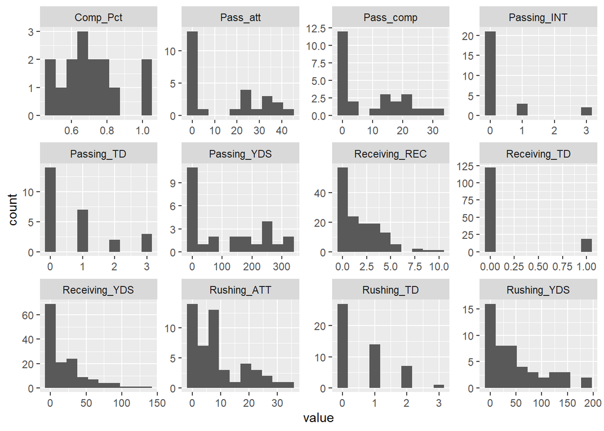

```r
library(ggplot2)
offClean %>% ggplot(aes(value)) + geom_histogram(bins = 10) + facet_wrap(~stat, scales = "free")
```

Almost all of the distributions seem like they have a higher amount of smaller values, and as the value for each stat increases, they become less common. The distributions for TD stats appear to be more discrete with smaller values, since they are harder to get.

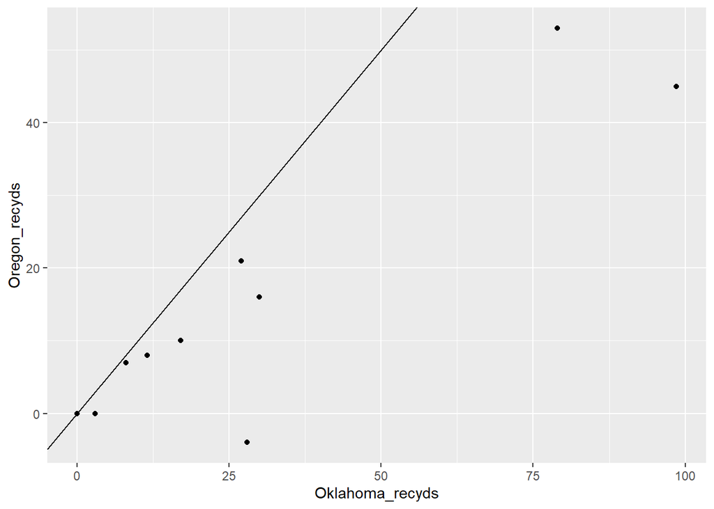

```r
OU_recyds = offClean %>% filter(Opponent_Opponent == "Oklahoma" & stat == "Receiving_YDS") %>% group_by(Name) %>% summarize(Oklahoma_recyds = mean(value))

Ore_recyds = offClean %>% filter(Opponent_Opponent == "Oregon" & stat == "Receiving_YDS") %>% mutate(Oregon_recyds = value)

recyd_compare = full_join(OU_recyds, Ore_recyds, by = "Name") %>% select(c("Name", "Oklahoma_recyds", "Oregon_recyds"))

recyd_compare %>% ggplot(aes(x=Oklahoma_recyds, y=Oregon_recyds)) + geom_point() + geom_abline(intercept = 0, slope = 1)
```

This scatterplot shows that every player averaged at least as many yards over the two Oklahoma games as they had in the Oregon game, if not more. This would indicate that ISU had better offense against Oklahoma than they did against Oregon.

```r
bioClean = bioClean %>% separate(Hometown, c("City", "State"), sep = ", ")

bioClean[1:5, c("City", "State")]
```

```
## # A tibble: 5 x 2
##   City           State
##   <chr>          <chr>
## 1 Cedar Rapids   Iowa
## 2 Nixa           Mo.
## 3 Seffner        Fla.
## 4 Ft. Lauderdale Fla.
## 5 Naperville     Ill.
```

```r
bioClean %>% group_by(State) %>% summarise(n = n())
```

```
## # A tibble: 21 x 2
##    State         n
##    <chr>     <int>
##  1 Ariz.         4
##  2 Ark.          1
##  3 Australia     1
##  4 Calif.        2
##  5 Fla.         14
##  6 Ga.           3
##  7 Ill.          6
##  8 Iowa         42
##  9 Kan.          4
## 10 Mich          1
## # ... with 11 more rows
```

## Part Three

```r
bioClean %>% group_by(State) %>% summarise(n = n()) %>% arrange(desc(n))
```

```
## # A tibble: 21 x 2
##    State     n
##    <chr> <int>
##  1 Iowa     42
##  2 Fla.     14
##  3 Minn.     8
##  4 Texas     7
##  5 Ill.      6
##  6 Ohio      6
##  7 Mo.       5
##  8 Ariz.     4
##  9 Kan.      4
## 10 Ga.       3
## # ... with 11 more rows
```

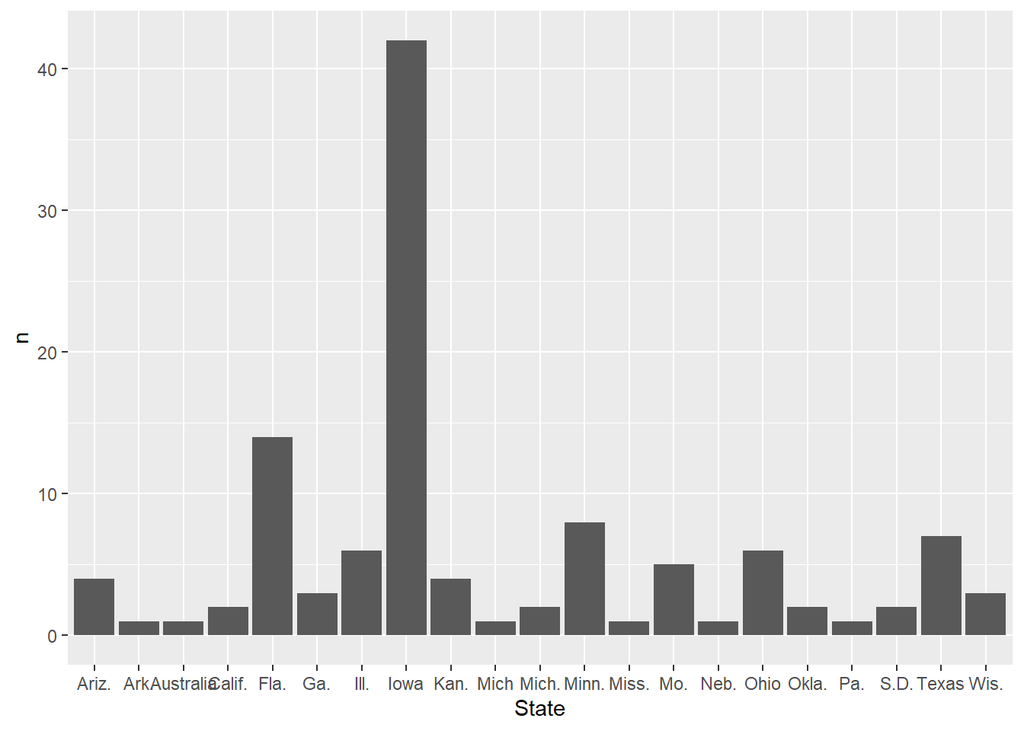

```r
bioClean %>% group_by(State) %>% summarise(n = n()) %>% ggplot(aes(x= State, y=n)) + geom_bar(stat="identity")
```

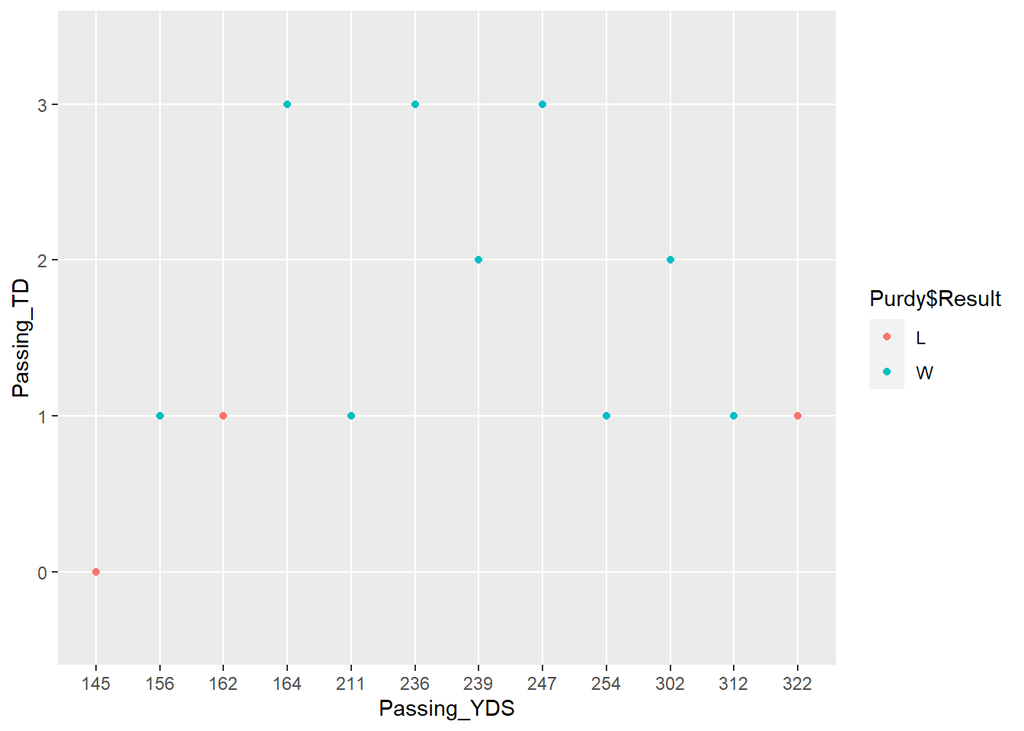

```r
Purdy = offense %>% filter(Name == "Purdy, Brock") %>% select(c("Name", "Opponent_Opponent", "Passing_YDS", "Passing_TD")) %>% mutate(Result = c("L", "W", "W", "W", "L", "W", "W", "W", "W", "W", "L", "W"))

ggplot(Purdy, aes(x=Passing_YDS, y=Passing_TD)) + geom_point(aes(color=Purdy$Result))
```

Here I went and added the result of the game to Purdy’s stats. I used his passing yards and passing touchdowns. We can see from the graph that if he throws at least two touchdowns, the team won every game. Two of the three fewest passing yards games resulted in losses. Interestingly, the team also lost the game where he threw for the most yards. Further analysis would show that he threw 3 interceptions in that game. So it is safe to say that the team played better when he played better.

```r
defense19 <- read_excel('cyclonesFootball2019.xlsx', sheet='Defensive')
str(defense)
```

```
## tibble [372 x 11] (S3: tbl_df/tbl/data.frame)
##  $ Name             : Factor w/ 37 levels "Akers, Landen",..: 26 26 26 26 26 26 26 26 26 26 ...
##  $ Opponent_Opponent: Factor w/ 11 levels "Baylor","Kansas",..: 4 8 5 10 6 2 1 3 9 11 ...
##  $ Tackles_Solo     : chr [1:372] "2" "6" "6" "3" ...
##  $ Tackles_ASST     : chr [1:372] "4" "4" "5" "0" ...
##  $ Tackles_TFL      : chr [1:372] "1.0" "0" "1.5" "1.0" ...
##  $ Tackles_Sack     : chr [1:372] "0" "0" "0.5" "0" ...
##  $ Turnover_FF      : chr [1:372] "0" "0" "0" "0" ...
##  $ Turnover_FR      : chr [1:372] "0" "0" "0" "0" ...
##  $ Turnover_INT     : chr [1:372] "0" "1" "0" "0" ...
##  $ Pass_QBH         : chr [1:372] "0" "0" "1" "0" ...
##  $ Pass_PB          : chr [1:372] "0" "0" "0" "0" ...
```

```r
offense19 <- read_excel('cyclonesFootball2019.xlsx', sheet='Offensive')
```

```r
defClean19 <-  defense19 %>% mutate(across(3:11, as.numeric))

defClean19$Total_Tackles = defClean19$Tackles_Solo + defClean19$Tackles_ASST

defClean$Total_Tackles = defClean$Tackles_Solo + defClean$Tackles_ASST
```

```r
tackles20 = defClean %>% group_by(Name) %>% summarise(tackles = sum(Total_Tackles)) %>% rename(tkl20 = tackles)

tackles19 = defClean19 %>% group_by(Name) %>% summarise(tackles = sum(Total_Tackles)) %>% rename(tkl19 = tackles)
```

```r
inner_join(tackles20, tackles19, by = "Name") %>% mutate(tkl_diff = tkl20 - tkl19) %>% arrange(desc(tkl_diff))
```

```
## # A tibble: 15 x 4
##    Name              tkl20 tkl19 tkl_diff
##    <chr>             <dbl> <dbl>    <dbl>
##  1 Hummel, Jake         77    36       41
##  2 Bailey, JaQuan       38    10       28
##  3 Vaughn, Gerry        24     3       21
##  4 Rose, Mike           96    77       19
##  5 Young, Datrone       25    19        6
##  6 Walling, Rory        14    11        3
##  7 Vance, O'Rien        68    66        2
##  8 King, Kym-Mani        8     7        1
##  9 Rus, Jared            2     1        1
## 10 Azunna, Arnold       29    30       -1
## 11 Kyle, Tayvonn        28    29       -1
## 12 Soehner, Dylan        1     3       -2
## 13 Akers, Landen         7    11       -4
## 14 Uwazurike, Eyioma    27    32       -5
## 15 Petersen, Zach       19    41      -22
```

On defense, I looked at who improved most in number of tackles for the season, and Jake Hummel had the largest increase, going from 36 to 77.

```r
offClean19 <- offense19 %>% mutate(across(3:12, as.numeric))
off20 = offense %>% mutate(across(3:14, as.numeric)) %>% select(c("Name", "Receiving_YDS", "Rushing_YDS")) %>% group_by(Name) %>% summarise(tot_rush20 = sum(Rushing_YDS), tot_rec20 = sum(Receiving_YDS))
```

```r
off19 = offClean19  %>% select(c("Name", "Receiving_YDS", "Rushing_YDS")) %>% group_by(Name) %>% summarise(tot_rush19 = sum(Rushing_YDS), tot_rec19 = sum(Receiving_YDS))
```

```r
off_diff = inner_join(off20, off19, by = "Name") %>% mutate(rush_diff = tot_rush20 - tot_rush19, rec_diff = tot_rec20 - tot_rec19)

off_diff %>% arrange(desc(rush_diff)) %>% select(c("Name", "rush_diff"))
```

```
## # A tibble: 11 x 2
##    Name            rush_diff
##    <chr>               <dbl>
##  1 Hall, Breece          675
##  2 Nwangwu, Kene         224
##  3 Purdy, Brock          133
##  4 Brock, Jirehl          -2
##  5 Akers, Landen          NA
##  6 Allen, Chase           NA
##  7 Kolar, Charlie         NA
##  8 Milton, Tarique        NA
##  9 Scates, Joe            NA
## 10 Shaw Jr., Sean         NA
## 11 Soehner, Dylan         NA
```

```r
off_diff %>% arrange(desc(rec_diff)) %>% select(c("Name", "rec_diff"))
```

```
## # A tibble: 11 x 2
##    Name            rec_diff
##    <chr>              <dbl>
##  1 Akers, Landen        160
##  2 Scates, Joe          109
##  3 Soehner, Dylan        98
##  4 Allen, Chase          69
##  5 Nwangwu, Kene         14
##  6 Shaw Jr., Sean       -19
##  7 Hall, Breece         -72
##  8 Kolar, Charlie      -106
##  9 Milton, Tarique     -620
## 10 Brock, Jirehl         NA
## 11 Purdy, Brock          NA
```

For offense, I looked at who gained the most yards year over year for both rushing and receiving. Breece Hall appears to be the most improved rusher, gaining 675 more yards in 2020 than 2019. Landon Akers appears to be the most improved receiver, gaining 160 more yards in 2020 than in 2019.